# Análise de Personalidade do Cliente

## 2.1 Detectando Valores ausentes (NA)

```r
func_my_summary(dados)
```

| Variavel | Tipo | N | Missing | Missing_Percent | N_unique |
| --- | --- | --- | --- | --- | --- |
| ID | integer | 2240 | 0 | 0.0 | 2240 |
| Year_Birth | integer | 2240 | 0 | 0.0 | 59 |
| Education | character | 2240 | 0 | 0.0 | 5 |
| Marital_Status | character | 2240 | 0 | 0.0 | 8 |
| Income | integer | 2240 | 24 | 1.1 | 1975 |
| Kidhome | integer | 2240 | 0 | 0.0 | 3 |
| Teenhome | integer | 2240 | 0 | 0.0 | 3 |
| Dt_Customer | character | 2240 | 0 | 0.0 | 663 |
| Recency | integer | 2240 | 0 | 0.0 | 100 |
| MntWines | integer | 2240 | 0 | 0.0 | 776 |

[output cut: 19 more lines]

```r
cat("Índices das linhas com valores ausentes para a variável Income: ",which(is.na(dados$Income)), "\nTotal de NA's:", sum(is.na(dados$Income)), sep = "\n" )
```

```
Índices das linhas com valores ausentes para a variável Income:
11
28
44
49
59
72
91
92
93
129
134
313
320
1380
1383
1384
1387
2060
2062
2079
2080
2082
2085
2229

Total de NA's:
24
```

```r
# Eliminar valores NA da variável Income
dados_1 <- dados %>% drop_na(Income)         #dados_1 é o data frame que sofrerá alteração nesta parte exploratória.

cat("Quantidade de valores ausentes (NA) após eliminação:", sum(is.na(dados_1)))
```

```
Quantidade de valores ausentes (NA) após eliminação: 0
```

## 2.2 Detectando valores duplicados

```r
cat("Quantidade de valores duplicados é:", sum(duplicated(dados_1)))
```

```
Quantidade de valores duplicados é: 0
```

## 2.3 Eliminar colunas indesejadas

```r
unique(dados_1$Z_CostContact)
```

```
[1] 3
```

```r
unique(dados_1$Z_Revenue)
```

```
[1] 11
```

```r
dados_1[,c("Z_CostContact","Z_Revenue")] <- NULL

cat('Após a exclusão das variáveis Z_CostContact e Z_Revenue, o data frame "dados_1" possui',
    dim(dados_1)[2],
    'colunas. Tais variáveis foram eliminadas por possuirem o mesmo valor para todas as observações.')
```

```
Após a exclusão das variáveis Z_CostContact e Z_Revenue, o data frame "dados_1" possui 27 colunas. Tais variáveis foram eliminadas por possuirem o mesmo valor para todas as observações.
```

## 2.4 Estatísticas

```r
my_summary_all(dados_1)
```

|  | ID | Year_Birth | Income | Kidhome | Teenhome | Recency | MntWines | MntFruits | MntMeatProducts | MntFishProducts | MntSweetProducts | MntGoldProds | NumDealsPurchases | NumWebPurchases | NumCatalogPurchases | NumStorePurchases | NumWebVisitsMonth | AcceptedCmp3 | AcceptedCmp4 | AcceptedCmp5 | AcceptedCmp1 | AcceptedCmp2 | Complain | Response |
| --- | --- | --- | --- | --- | --- | --- | --- | --- | --- | --- | --- | --- | --- | --- | --- | --- | --- | --- | --- | --- | --- | --- | --- | --- |
| Min | 0.00 | 1893.00 | 1730.00 | 0.00 | 0.00 | 0.00 | 0.00 | 0.00 | 0.00 | 0.00 | 0.00 | 0.00 | 0.00 | 0.00 | 0.00 | 0.00 | 0.00 | 0.00 | 0.00 | 0.00 | 0.00 | 0.00 | 0.00 | 0.00 |
| Q1 | 2814.75 | 1959.00 | 35303.00 | 0.00 | 0.00 | 24.00 | 24.00 | 2.00 | 16.00 | 3.00 | 1.00 | 9.00 | 1.00 | 2.00 | 0.00 | 3.00 | 3.00 | 0.00 | 0.00 | 0.00 | 0.00 | 0.00 | 0.00 | 0.00 |
| Mediana | 5458.50 | 1970.00 | 51381.50 | 0.00 | 0.00 | 49.00 | 174.50 | 8.00 | 68.00 | 12.00 | 8.00 | 24.50 | 2.00 | 4.00 | 2.00 | 5.00 | 6.00 | 0.00 | 0.00 | 0.00 | 0.00 | 0.00 | 0.00 | 0.00 |
| Media | 5588.35 | 1968.82 | 52247.25 | 0.44 | 0.51 | 49.01 | 305.09 | 26.36 | 167.00 | 37.64 | 27.03 | 43.97 | 2.32 | 4.09 | 2.67 | 5.80 | 5.32 | 0.07 | 0.07 | 0.07 | 0.06 | 0.01 | 0.01 | 0.15 |
| Q3 | 8421.75 | 1977.00 | 68522.00 | 1.00 | 1.00 | 74.00 | 505.00 | 33.00 | 232.25 | 50.00 | 33.00 | 56.00 | 3.00 | 6.00 | 4.00 | 8.00 | 7.00 | 0.00 | 0.00 | 0.00 | 0.00 | 0.00 | 0.00 | 0.00 |
| Max | 11191.00 | 1996.00 | 666666.00 | 2.00 | 2.00 | 99.00 | 1493.00 | 199.00 | 1725.00 | 259.00 | 262.00 | 321.00 | 15.00 | 27.00 | 28.00 | 13.00 | 20.00 | 1.00 | 1.00 | 1.00 | 1.00 | 1.00 | 1.00 | 1.00 |
| DevPad | 3249.38 | 11.99 | 25173.08 | 0.54 | 0.54 | 28.95 | 337.33 | 39.79 | 224.28 | 54.75 | 41.07 | 51.82 | 1.92 | 2.74 | 2.93 | 3.25 | 2.43 | 0.26 | 0.26 | 0.26 | 0.24 | 0.12 | 0.10 | 0.36 |
| N_missing | 0.00 | 0.00 | 0.00 | 0.00 | 0.00 | 0.00 | 0.00 | 0.00 | 0.00 | 0.00 | 0.00 | 0.00 | 0.00 | 0.00 | 0.00 | 0.00 | 0.00 | 0.00 | 0.00 | 0.00 | 0.00 | 0.00 | 0.00 | 0.00 |

# 3 Análises univariadas

## 3.1 ID (Identificador único do cliente)

```r
summary(dados_1$ID)
```

```
   Min. 1st Qu.  Median    Mean 3rd Qu.    Max.
      0    2815    5458    5588    8422   11191
```

```r
cat("Quantidade de valores distintos em ID é igual a",
    length(unique(dados_1$ID)),"em um total de",dim(dados_1)[1],
    "linhas/valores.\n\nQuantidade de valores duplicados:",
    sum(duplicated(dados_1$ID)))
```

```
Quantidade de valores distintos em ID é igual a 2216 em um total de 2216 linhas/valores.

Quantidade de valores duplicados: 0
```

## 3.2 Year_Birth (Ano de nascimento do cliente)

```r
summary(dados_1$Year_Birth)
```

```
   Min. 1st Qu.  Median    Mean 3rd Qu.    Max.
   1893    1959    1970    1969    1977    1996
```

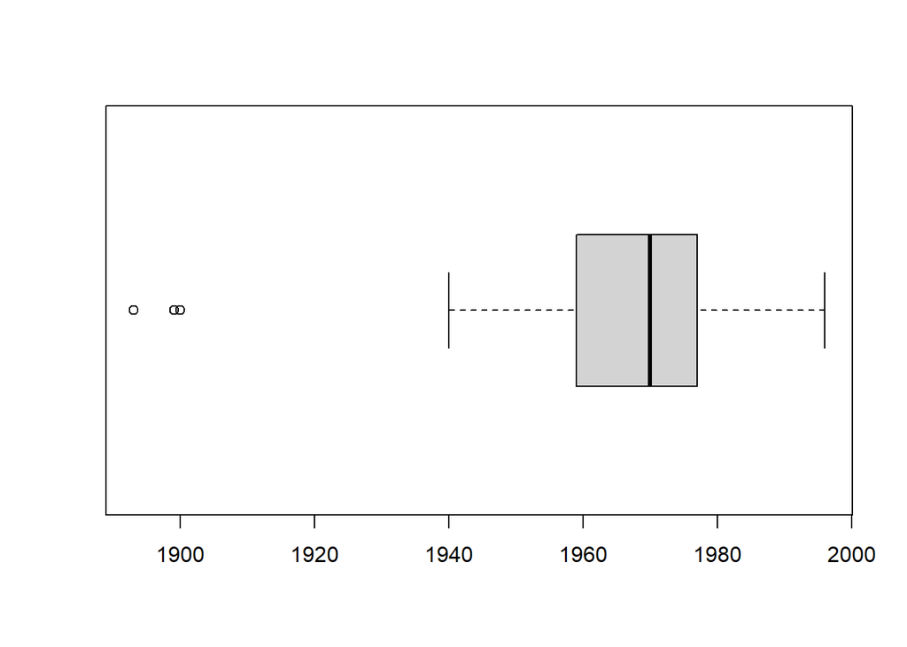

```r
boxplot(dados_1$Year_Birth,horizontal = T)
```

```r
# Calcular a idade do cliente
dados_1$Idade <- round(year(Sys.Date())-dados_1$Year_Birth, digits = 2)

summary(dados_1$Idade)
```

```
   Min. 1st Qu.  Median    Mean 3rd Qu.    Max.
  26.00   45.00   52.00   53.18   63.00  129.00
```

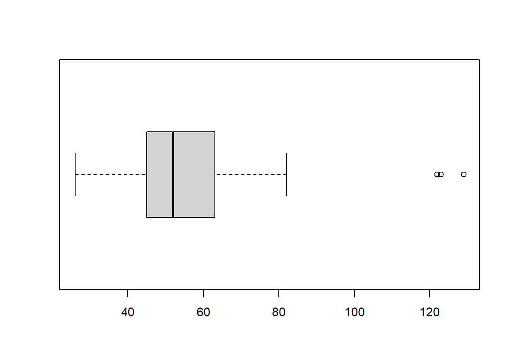

```r
boxplot(dados_1$Idade,horizontal = T)
```

```r
# Percebe-se clientes com idade muito elevada
```

```r
dados_1 <- dados_1[dados_1$Idade < 120,]

summary(dados_1$Idade)
```

```
   Min. 1st Qu.  Median    Mean 3rd Qu.    Max.
  26.00   45.00   52.00   53.08   63.00   82.00
```

```r
# as dez idades mais frequentes
head(dados_1 %>% count(Idade) %>% arrange(desc(n)),10)
```

|  | Idade | n |
| --- | --- | --- |
| 1 | 46 | 89 |
| 2 | 51 | 86 |
| 3 | 47 | 83 |
| 4 | 50 | 78 |
| 5 | 44 | 76 |
| 6 | 52 | 75 |
| 7 | 57 | 74 |
| 8 | 49 | 72 |
| 9 | 53 | 70 |
| 10 | 48 | 69 |

## 3.3 Education (Nível de instrução do cliente)

```r
# Corrigir categorias da variável Education
dados_1$Education[dados_1$Education %in% c("Basic","2n Cycle")] <- "Undergraduate"
dados_1$Education[dados_1$Education %in% c("Graduation","Master","PhD")] <- "Postgraduate"

cat("As categorias existentes em Education são:\n",
    unique(dados_1$Education),sep = "\n")
```

```
As categorias existentes em Education são:

Postgraduate
Undergraduate
```

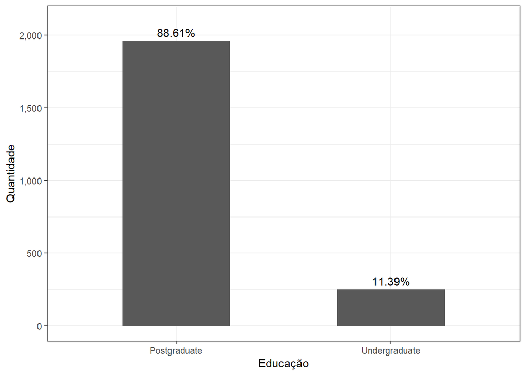

```r
# Quantidade de Undergraduate e Postgraduate
n_educacao <- dados_1 %>% count(Education) %>% mutate(percentage= n/dim(dados_1)[1],
                      percent_lab = paste0(round(percentage*100,2),"%"))

ggplot(data = n_educacao) +
  geom_col(aes(x = Education, y = n), width =0.5) +
  labs(x = "Educação",y = "Quantidade") +
  theme_bw() +
  geom_text(aes(x = Education, y = n,label=percent_lab), vjust = -0.5) +
  scale_y_continuous(limits = c(0,2100), labels = scales::comma)
```

## 3.4 Marital_Status (Estado civil do cliente)

```r
unique(dados_1$Marital_Status)
```

```
[1] "Single"   "Together" "Married"  "Divorced" "Widow"    "Alone"    "Absurd"
[8] "YOLO"
```

```r
# COrrigir classes da variável Marital_Status
dados_1$Marital_Status[dados_1$Marital_Status %in% c("Single","Divorced","Absurd","Widow","YOLO")] <- "Alone"
dados_1$Marital_Status[dados_1$Marital_Status %in% c("Married","Together")] <- "In couple"

cat("As classificações para o estado civil são: \n",unique(dados_1$Marital_Status)[1],unique(dados_1$Marital_Status)[2], sep = "\n")
```

```
As classificações para o estado civil são:

Alone
In couple
```

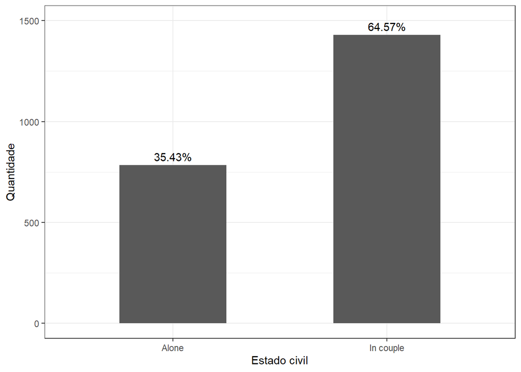

```r
# Quantidade de Alone e In couple
n_marital <- dados_1 %>% count(Marital_Status) %>%
  mutate(percentage = n/dim(dados_1)[1],
          percent_lab = paste0(round(percentage*100,2),"%"))

ggplot(data = n_marital) +
  geom_col(aes(x = Marital_Status, y = n), width =0.5) +
  labs(x = "Estado civil",y = "Quantidade") +
  theme_bw() +
  geom_text(aes(x = Marital_Status, y = n,label=percent_lab), vjust = -0.5) +
  scale_y_continuous(limits = c(0,1500))
```

## 3.5 Income (Renda familiar anual do cliente)

```r
summary(dados_1$Income)
```

```
   Min. 1st Qu.  Median    Mean 3rd Qu.    Max.
   1730   35246   51373   52237   68487  666666
```

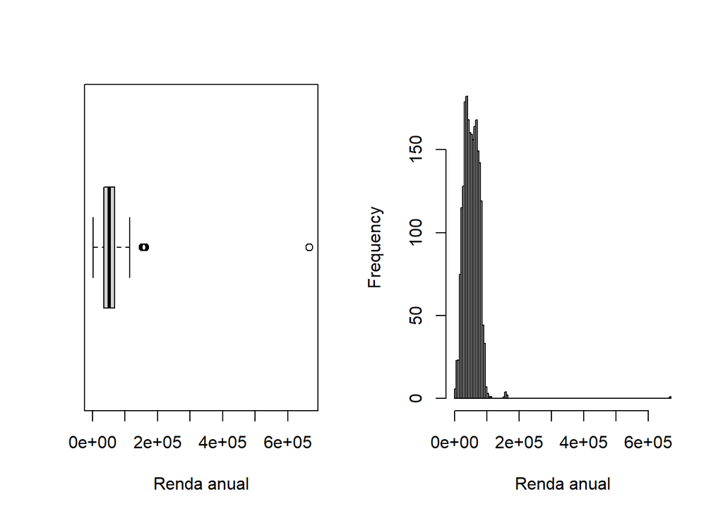

```r
par(mfrow = c(1,2))
boxplot(dados_1$Income, horizontal = T,xlab = "Renda anual")
hist(dados_1$Income,breaks = 100, main = NULL,xlab = "Renda anual")
```

```r
# Existe a presença de outliers!!!
```

```r
# Eliminar valor discrepante da variável Income
dados_1 <- dados_1[dados_1$Income < 600000,]
```

```r
summary(dados_1$Income)
```

```
   Min. 1st Qu.  Median    Mean 3rd Qu.    Max.
   1730   35234   51371   51959   68487  162397
```

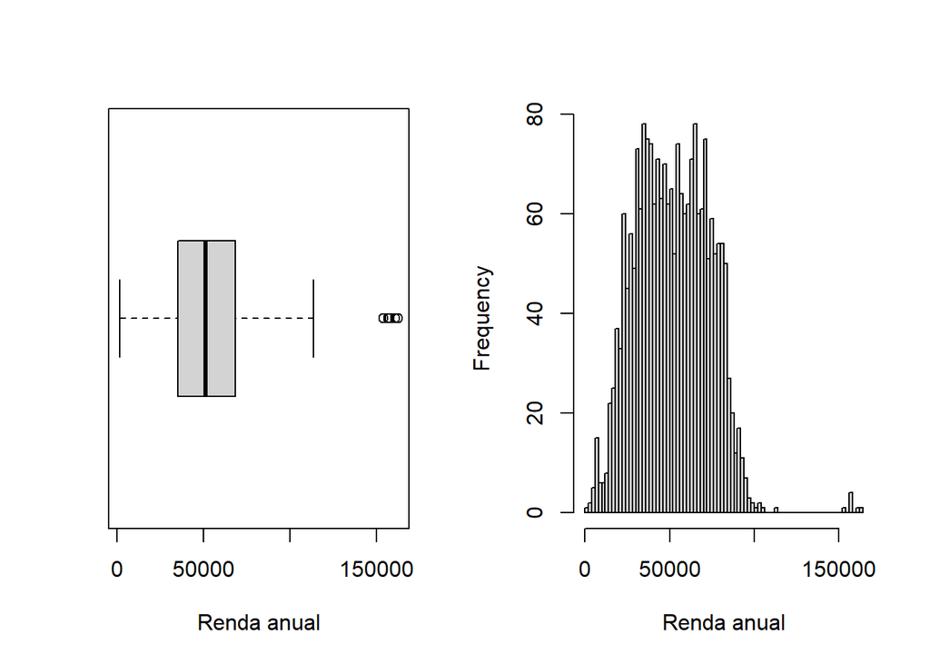

```r
par(mfrow = c(1,2))
boxplot(dados_1$Income, horizontal = T, xlab = "Renda anual")
hist(dados_1$Income,breaks = 100,xlab = "Renda anual", main = NULL)
```

## 3.6 Kidhome e Teenhome (Número de crianças e adolescentes na residência do cliente)

```r
unique(dados_1$Kidhome)
```

```
[1] 0 1 2
```

```r
unique(dados_1$Teenhome)
```

```
[1] 0 1 2
```

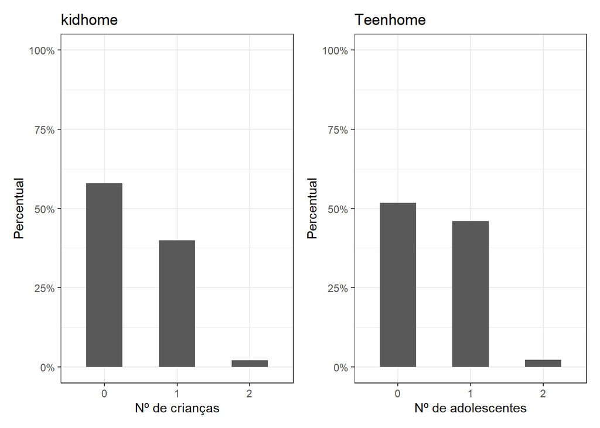

```r
percent_kidhome <- as.data.frame(prop.table(table(dados_1$Kidhome)))
g1 <- ggplot(data = percent_kidhome) +
  geom_col(aes(x = Var1, y = Freq), width =0.5) +
  labs(x="Nº de crianças",y = "Percentual", title = "kidhome") +
  scale_y_continuous(limits = c(0,1), labels = scales::percent) +
  theme_bw()

percent_Teenhome <- as.data.frame(prop.table(table(dados_1$Teenhome)))
g2 <- ggplot(data = percent_Teenhome) +
  geom_col(aes(x = Var1, y = Freq), width =0.5) +
  labs(x="Nº de adolescentes",y = "Percentual", title = "Teenhome") +
  scale_y_continuous(limits = c(0,1), labels = scales::percent) +
  theme_bw()
(g1+g2)
```

```r
# Cálculo do total de Filhos
dados_1$N_Children <- dados_1$Kidhome + dados_1$Teenhome
```

```r
dados_1$Has_Children <- ifelse(dados_1$N_Children > 0,"Has child","No child")
unique(dados_1$Has_Children)
```

```
[1] "No child"  "Has child"
```

```r
dados_1$Children <- ifelse(dados_1$N_Children == 3, "3 children",
                                ifelse(dados_1$N_Children == 2, "2 children",
                                       ifelse(dados_1$N_Children == 1, "1 children",
                                              "No children")))
unique(dados_1$N_Children); unique(dados_1$Children)
```

```
[1] 0 2 1 3
```

```
[1] "No children" "2 children"  "1 children"  "3 children"
```

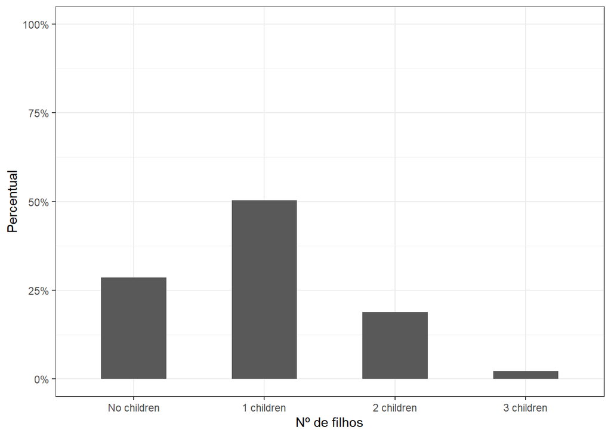

```r
percent_Children <- as.data.frame(prop.table(table(dados_1$Children)))
percent_Children$Var1 <- factor(percent_Children$Var1,
                                   levels= c("No children","1 children",
                                             "2 children","3 children"))

ggplot(data = percent_Children) +
  geom_col(aes(x = Var1, y = Freq), width =0.5) +
  labs(x="Nº de filhos",y = "Percentual") +
  scale_y_continuous(limits = c(0,1),labels = scales::percent_format(scale = 100,accuracy =5L)) +
  theme_bw()
```

## 3.7 Dt_Customer (Data do cadastro do cliente na empresa)

```r
dados_1$Dt_Customer <- as_date(dmy(dados_1$Dt_Customer))
class(dados_1$Dt_Customer)
```

```
[1] "Date"
```

```r
#(min(dados_1$Dt_Customer) %--% max(dados_1$Dt_Customer) %/% days(x=1))/365
summary(dados_1$Dt_Customer)
```

```
        Min.      1st Qu.       Median         Mean      3rd Qu.         Max.
"2012-07-30" "2013-01-16" "2013-07-08" "2013-07-10" "2013-12-31" "2014-06-29"
```

```r
# quantidade de dias desde a inscrição do cliente na empresa até o dia atual
dados_1$Dt_inscricao_ate_atual <- Sys.Date() - dados_1$Dt_Customer
dados_1$Dt_inscricao_ate_atual <- as.numeric(dados_1$Dt_inscricao_ate_atual)

summary(dados_1$Dt_inscricao_ate_atual)
```

```
   Min. 1st Qu.  Median    Mean 3rd Qu.    Max.
   2847    3027    3203    3201    3376    3546
```

## 3.8 Recency (Quantidade de dias desde a última compra do cliente)

```r
summary(dados_1$Recency)
```

```
   Min. 1st Qu.  Median    Mean 3rd Qu.    Max.
   0.00   24.00   49.00   49.02   74.00   99.00
```

## 3.9 Variáveis MntWines, MntFruits, MntMeatProducts, MntFishProducts, MntSweetProducts e MntGoldProds

```r
summary(dados_1$MntWines)
```

```
   Min. 1st Qu.  Median    Mean 3rd Qu.    Max.
    0.0    24.0   175.5   305.3   505.0  1493.0
```

```r
summary(dados_1$MntFruits)
```

```
   Min. 1st Qu.  Median    Mean 3rd Qu.    Max.
   0.00    2.00    8.00   26.33   33.00  199.00
```

```r
summary(dados_1$MntMeatProducts)
```

```
   Min. 1st Qu.  Median    Mean 3rd Qu.    Max.
    0.0    16.0    68.0   167.0   232.2  1725.0
```

```r
summary(dados_1$MntFishProducts)
```

```
   Min. 1st Qu.  Median    Mean 3rd Qu.    Max.
   0.00    3.00   12.00   37.65   50.00  259.00
```

```r
summary(dados_1$MntSweetProducts)
```

```
   Min. 1st Qu.  Median    Mean 3rd Qu.    Max.
   0.00    1.00    8.00   27.05   33.00  262.00
```

```r
summary(dados_1$MntGoldProds)
```

```
   Min. 1st Qu.  Median    Mean 3rd Qu.    Max.
   0.00    9.00   24.50   43.93   56.00  321.00
```

```r
# Calcular a quantia total gasta nos últimos 2 anos
dados_1$Gasto_total <- dados_1$MntWines + dados_1$MntFruits + dados_1$MntMeatProducts +
  dados_1$MntFishProducts + dados_1$MntSweetProducts + dados_1$MntGoldProds

# MntWines: Amount spent on wine in last 2 years
# MntFruits: Amount spent on fruits in last 2 years
# MntMeatProducts: Amount spent on meat in last 2 years
# MntFishProducts: Amount spent on fish in last 2 years
# MntSweetProducts: Amount spent on sweets in last 2 years
# MntGoldProds: Amount spent on gold in last 2 years
```

```r
summary(dados_1$Gasto_total)
```

```
   Min. 1st Qu.  Median    Mean 3rd Qu.    Max.
    5.0    69.0   397.0   607.3  1048.0  2525.0
```

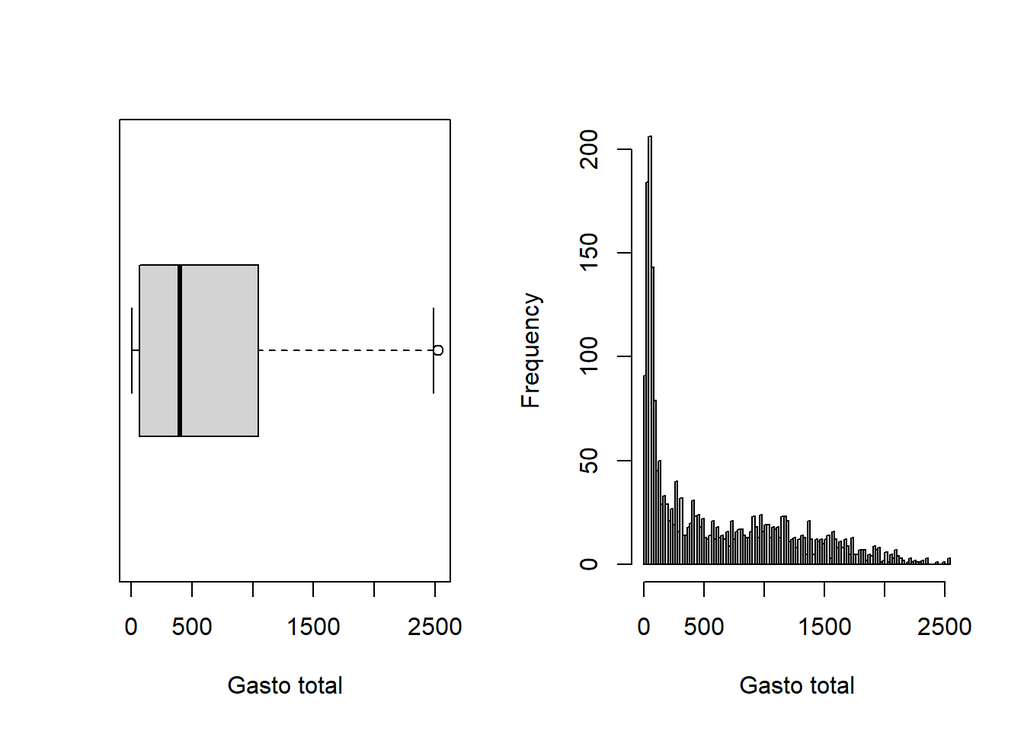

```r
par(mfrow = c(1,2))
boxplot(dados_1$Gasto_total,horizontal = T,xlab ="Gasto total")
hist(dados_1$Gasto_total, breaks = 100,xlab ="Gasto total", main = NULL)
```

```r
head(dados_1 %>% arrange(desc(Gasto_total)) %>%
  select("Marital_Status","Education","Idade","Income","Gasto_total"),10)
```

|  | Marital_Status | Education | Idade | Income | Gasto_total |
| --- | --- | --- | --- | --- | --- |
| 1 | Alone | Postgraduate | 31 | 90638 | 2525 |
| 2 | Alone | Postgraduate | 31 | 90638 | 2525 |
| 3 | In couple | Postgraduate | 34 | 87679 | 2524 |
| 4 | In couple | Postgraduate | 53 | 75759 | 2486 |
| 5 | In couple | Postgraduate | 73 | 69098 | 2440 |
| 6 | In couple | Postgraduate | 66 | 90226 | 2352 |
| 7 | Alone | Postgraduate | 52 | 93790 | 2349 |
| 8 | In couple | Postgraduate | 50 | 83151 | 2346 |
| 9 | In couple | Postgraduate | 69 | 94384 | 2302 |
| 10 | In couple | Postgraduate | 69 | 94384 | 2302 |

## 3.10 NumDealsPurchases (Número de compras feitas com desconto)

```r
summary(dados_1$NumDealsPurchases)
```

```
   Min. 1st Qu.  Median    Mean 3rd Qu.    Max.
  0.000   1.000   2.000   2.325   3.000  15.000
```

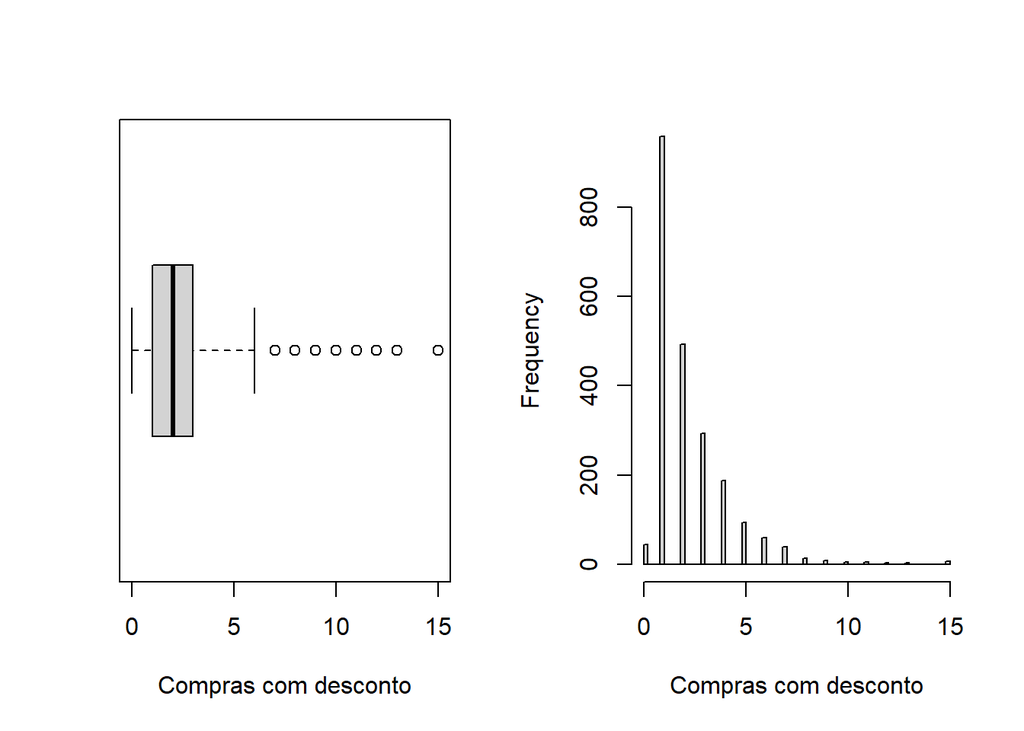

```r
par(mfrow = c(1,2))
boxplot(dados_1$NumDealsPurchases, horizontal = T,xlab ="Compras com desconto")
hist(dados_1$NumDealsPurchases, breaks = 100,xlab ="Compras com desconto", main = NULL)
```

```r
# Quantidade de compra realizada com desconto
dados_1 %>% count(NumDealsPurchases)
```

| NumDealsPurchases | n |
| --- | --- |
| 0 | 44 |
| 1 | 957 |
| 2 | 493 |
| 3 | 293 |
| 4 | 187 |
| 5 | 94 |
| 6 | 60 |
| 7 | 39 |
| 8 | 14 |
| 9 | 8 |

[output cut: 5 more lines]

## 3.11 NumWebPurchases, NumCatalogPurchases e NumStorePurchases

```r
# Número total de compras por cliente
dados_1$Numero_compras <- dados_1$NumWebPurchases + dados_1$NumCatalogPurchases +
  dados_1$NumStorePurchases
```

```r
summary(dados_1$Numero_compras)
```

```
   Min. 1st Qu.  Median    Mean 3rd Qu.    Max.
   0.00    6.00   12.00   12.57   18.25   32.00
```

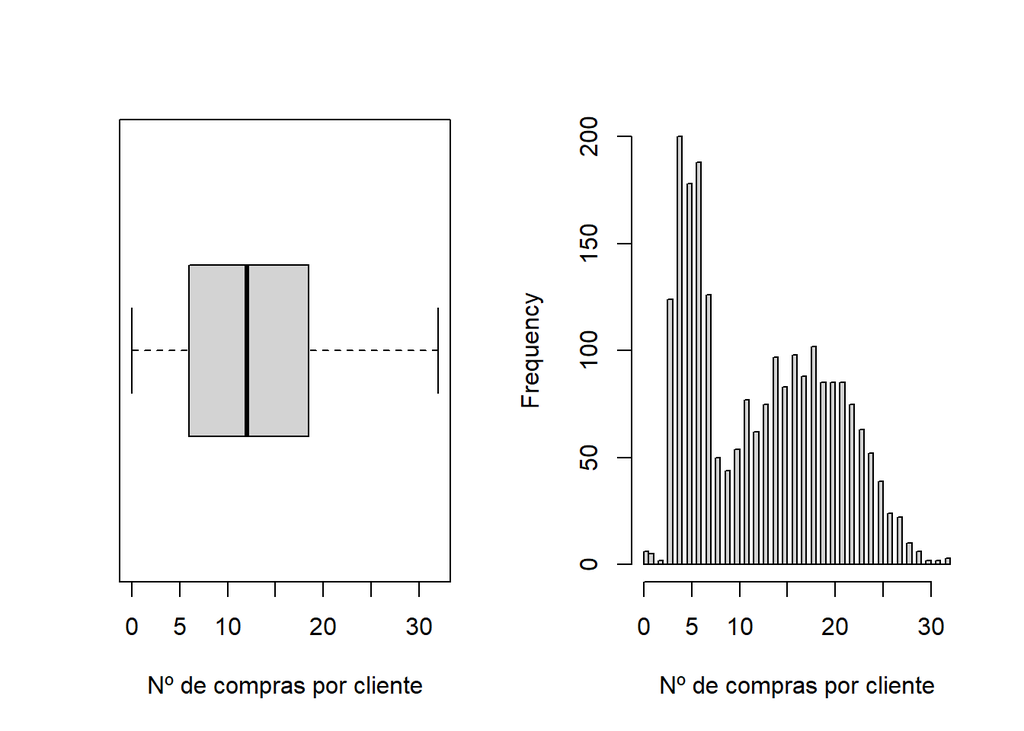

```r
par(mfrow = c(1,2))
boxplot(dados_1$Numero_compras,xlab ="Nº de compras por cliente", horizontal = T)
hist(dados_1$Numero_compras, breaks = 100,xlab ="Nº de compras por cliente", main = NULL)
```

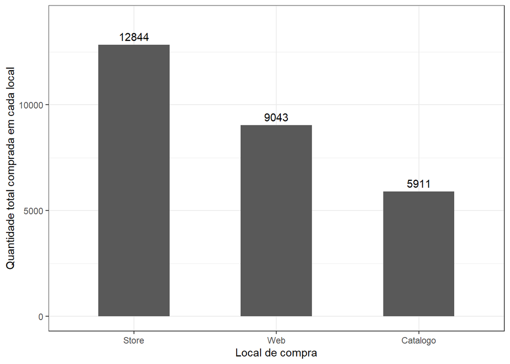

```r
local <- c("Web","Catalogo","Store")
valor <- c(sum(dados_1$NumWebPurchases),
           sum(dados_1$NumCatalogPurchases),
           sum(dados_1$NumStorePurchases))
local_vendas <- data.frame(local,valor)
local_vendas$local <- factor(local_vendas$local, levels = c("Catalogo","Web","Store"))

ggplot(data = local_vendas) +
  geom_col(aes(x = reorder(local,-valor), y = valor), width = 0.5) +
  labs(x = "Local de compra",y = "Quantidade total comprada em cada local") +
  theme_bw() + geom_text(aes(x = local, y = valor,label=valor), vjust = -0.5) +
  scale_y_continuous(limits = c(0,14000))
```

## 3.12 NumWebVisitsMonth (Número de visitas ao site da empresa no último mês)

```r
summary(dados_1$NumWebVisitsMonth)
```

```
   Min. 1st Qu.  Median    Mean 3rd Qu.    Max.
  0.000   3.000   6.000   5.321   7.000  20.000
```

## 3.13 Variáveis AcceptedCmp1, AcceptedCmp2, AcceptedCmp3, AcceptedCmp4 e AcceptedCmp5

```r
unique(dados_1$AcceptedCmp1)
```

```
[1] 0 1
```

```r
unique(dados_1$AcceptedCmp2)
```

```
[1] 0 1
```

```r
unique(dados_1$AcceptedCmp3)
```

```
[1] 0 1
```

```r
unique(dados_1$AcceptedCmp4)
```

```
[1] 0 1
```

```r
unique(dados_1$AcceptedCmp5)
```

```
[1] 0 1
```

```r
# AcceptedCmp1: 1 if customer accepted the offer in the 1st campaign, 0 otherwise
# AcceptedCmp2: 1 if customer accepted the offer in the 2nd campaign, 0 otherwise
# AcceptedCmp3: 1 if customer accepted the offer in the 3rd campaign, 0 otherwise
# AcceptedCmp4: 1 if customer accepted the offer in the 4th campaign, 0 otherwise
# AcceptedCmp5: 1 if customer accepted the offer in the 5th campaign, 0 otherwise
```

```r
dados_1$Num_campaign_acc <- dados_1$AcceptedCmp1 + dados_1$AcceptedCmp2 + dados_1$AcceptedCmp3 + dados_1$AcceptedCmp4 + dados_1$AcceptedCmp5

unique(dados_1$Num_campaign_acc)
```

```
[1] 0 1 2 3 4
```

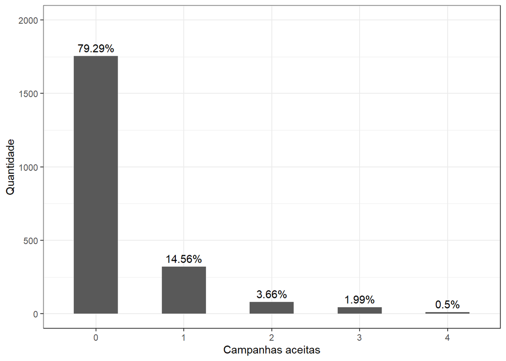

```r
n_campaign_acc <- dados_1 %>% count(Num_campaign_acc) %>% mutate(perc_camp = n/sum(n),
                                                                 perc_lab = paste0(round(perc_camp*100,2),"%"))
n_campaign_acc$Num_campaign_acc <-  as.factor(n_campaign_acc$Num_campaign_acc)

ggplot(data = n_campaign_acc) +
  geom_col(aes(x = Num_campaign_acc, y = n), width = 0.5) +
  labs(x = "Campanhas aceitas",y = "Quantidade") +
  theme_bw() + geom_text(aes(x = Num_campaign_acc, y = n,label=perc_lab), vjust = -0.5) +
  scale_y_continuous(limits = c(0,2000))
```

## 3.14 Complain (1 se o cliente reclamou nos últimos 2 anos, 0 caso contrário)

```r
unique(dados_1$Complain)
```

```
[1] 0 1
```

```r
cat("Foram feitas um total de",sum(dados_1$Complain),"reclamações.")
```

```
Foram feitas um total de 20 reclamações.
```

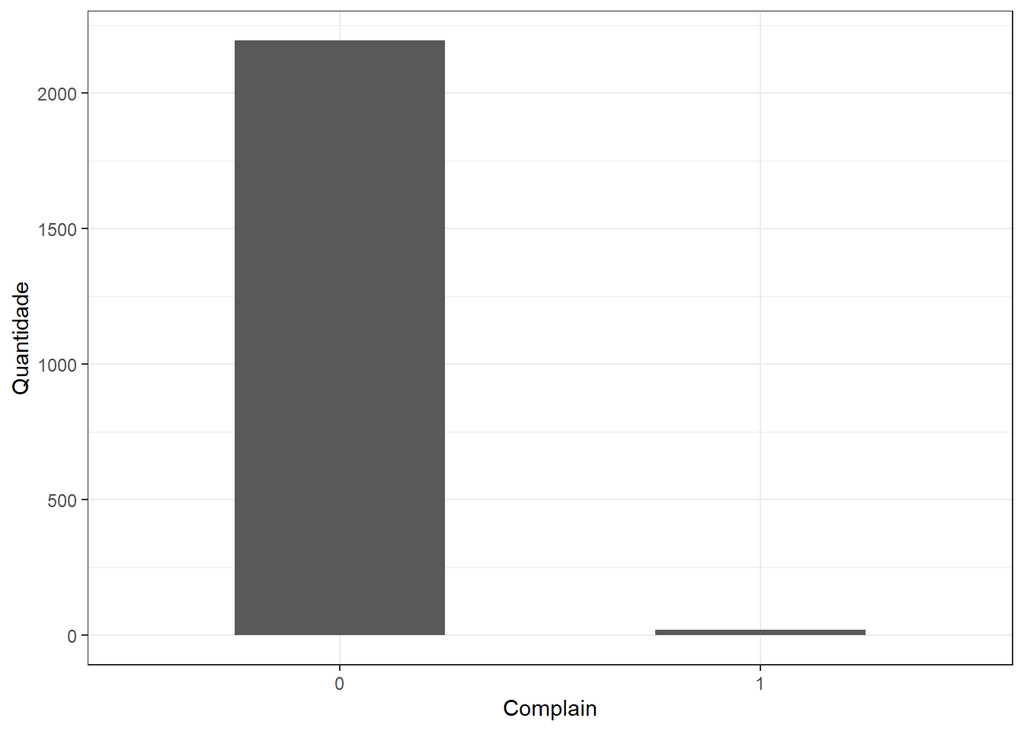

```r
n_complain <- dados_1 %>% count(Complain)
n_complain$Complain <-  as.factor(n_complain$Complain)

ggplot(data = n_complain) +
  geom_col(aes(x = Complain, y = n), width = 0.5) +
  labs(x = "Complain",y = "Quantidade") +
  theme_bw()
```

## 3.15 Response (1 se o cliente aceitou a oferta na última campanha, 0 caso contrário)

```r
unique(dados_1$Response)
```

```
[1] 1 0
```

```r
cat("Foram aceitas um total de",sum(dados_1$Response),"ofertas na última campanha.")
```

```
Foram aceitas um total de 333 ofertas na última campanha.
```

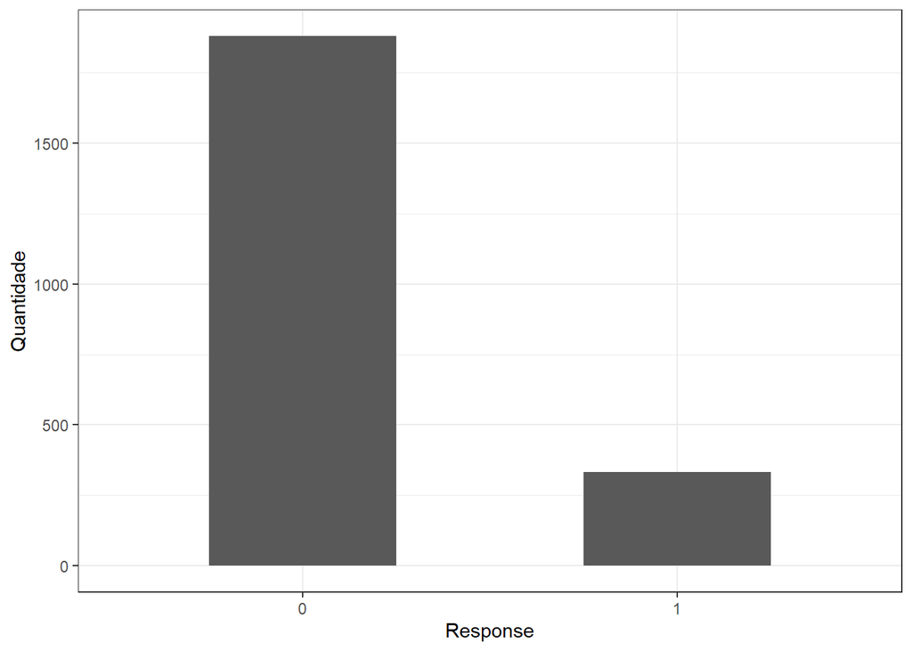

```r
n_response <- dados_1 %>% count(Response)
n_response$Response <-  as.factor(n_response$Response)

ggplot(data = n_response) +
  geom_col(aes(x = Response, y = n), width = 0.5) +
  labs(x = "Response",y = "Quantidade") +
  theme_bw()
```

## 3.16 Prosseguir apenas com as colunas que seja de interesse para as análies

```r
dados_2 <- dados_1 %>% select(-c("ID","Kidhome","Teenhome","MntWines","MntFruits",                                                          "MntMeatProducts","MntFishProducts","MntSweetProducts","MntGoldProds",
                    "NumWebPurchases","NumCatalogPurchases","NumStorePurchases",
                    "AcceptedCmp3","AcceptedCmp4","AcceptedCmp5","AcceptedCmp1",
                    "AcceptedCmp2"))

df_eda <- dados_2 %>% select("Year_Birth","Idade","Dt_Customer","Dt_inscricao_ate_atual",
                             "Education","Marital_Status","Has_Children","N_Children",
                             "Children","Income","Gasto_total","Numero_compras",
                             "Num_campaign_acc","NumDealsPurchases","NumWebVisitsMonth",
                             "Recency","Complain","Response")
```

## 3.17 Calcular o valor médio por compra

```r
df_eda_1 <- df_eda[df_eda$Numero_compras > 0,]  #são eliminas apenas 6 linhas

# Número médio de compra por cliente
df_eda_1$Valor_medio_de_compra <- round(df_eda_1$Gasto_total/df_eda_1$Numero_compras,
                                       digits = 2)
```

# 4 Análise gráfica

## 4.1 Gráfico de barras

### 4.1.1 Nível educacional x Gasto_total

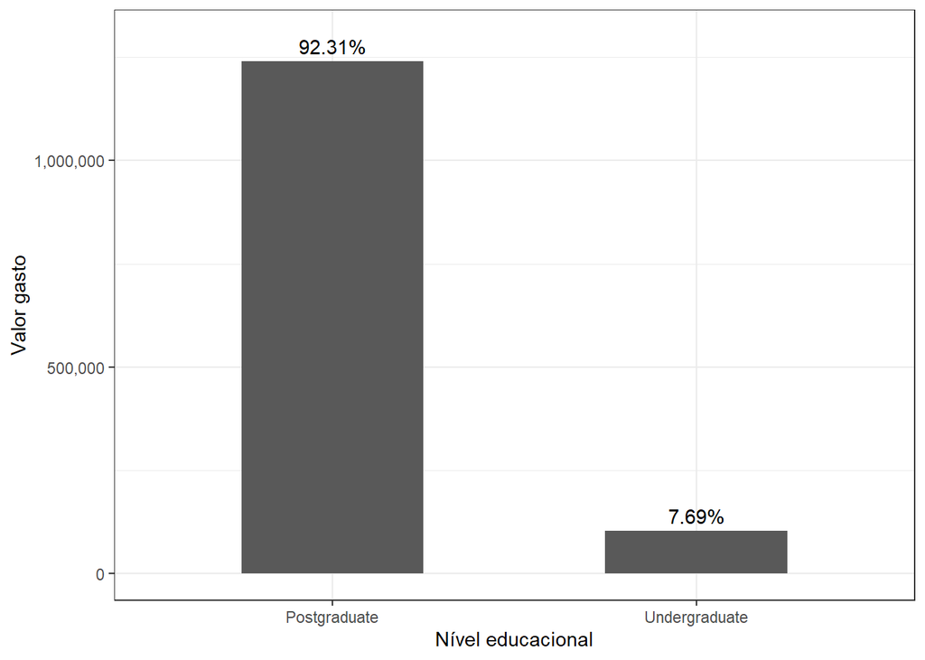

```r
# Gasto por nível educacional
Gst_niv_educ <- df_eda_1 %>% group_by(Education) %>% summarise(Gasto_Edu = sum(Gasto_total)) %>%
  mutate(perc_gasto = Gasto_Edu/sum(Gasto_Edu),
         perc_lab = paste0(round(perc_gasto*100,2),"%"))

ggplot(data = Gst_niv_educ) +
  geom_col(aes(x = Education,y = Gasto_Edu), width = 0.5) +
  labs(x="Nível educacional",y = "Valor gasto") +
  theme_bw() + geom_text(aes(x = Education,y = Gasto_Edu,label=perc_lab), vjust = -0.5) +
  scale_y_continuous(limits = c(0,1300000), labels = scales::comma)
```

### 4.1.2 Estado civil x Gasto_total

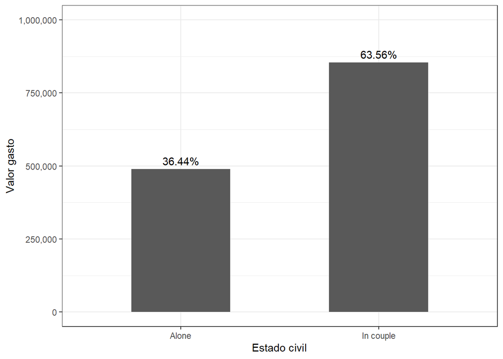

```r
# gasto por estado civil
Gst_est_civ <- df_eda_1 %>% group_by(Marital_Status) %>% summarise(Gasto_Marital = sum(Gasto_total)) %>%
  mutate(perc_gasto = Gasto_Marital/sum(Gasto_Marital),
         perc_lab = paste0(round(perc_gasto*100,2),"%"))

ggplot(data = Gst_est_civ) +
  geom_col(aes(x = Marital_Status,y = Gasto_Marital), width = 0.5) +
  labs(x="Estado civil",y = "Valor gasto") +
  theme_bw()  + geom_text(aes(x = Marital_Status,y = Gasto_Marital,label=perc_lab), vjust = -0.5) +
  scale_y_continuous(limits = c(0,1000000), labels = scales::comma)
```

### 4.1.3 Número de filhos x Gasto_total

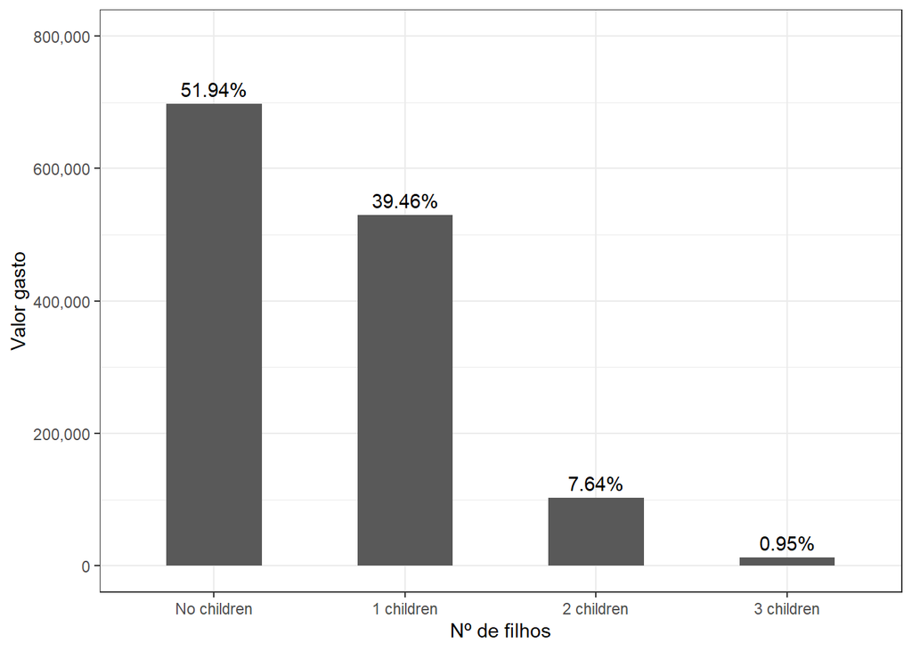

```r
# gasto por quantidade de filhos
Gst_n_Children <- df_eda_1 %>% group_by(Children) %>% summarise(Gasto_Child = sum(Gasto_total)) %>%
  mutate(perc_gasto = Gasto_Child/sum(Gasto_Child),
         perc_lab = paste0(round(perc_gasto*100,2),"%"))


Gst_n_Children$Children <- factor(Gst_n_Children$Children, levels = c("No children","1 children","2 children","3 children"))

ggplot(data = Gst_n_Children) +
  geom_col(aes(x = Children,y = Gasto_Child), width = 0.5) +
  labs(x = "Nº de filhos",y = "Valor gasto") +
  theme_bw()  + geom_text(aes(x = Children,y = Gasto_Child,label=perc_lab), vjust = -0.5) +
  scale_y_continuous(limits = c(0,800000), labels = scales::comma)
```

### 4.1.4 Número de campanhas aceitas x Gasto_total

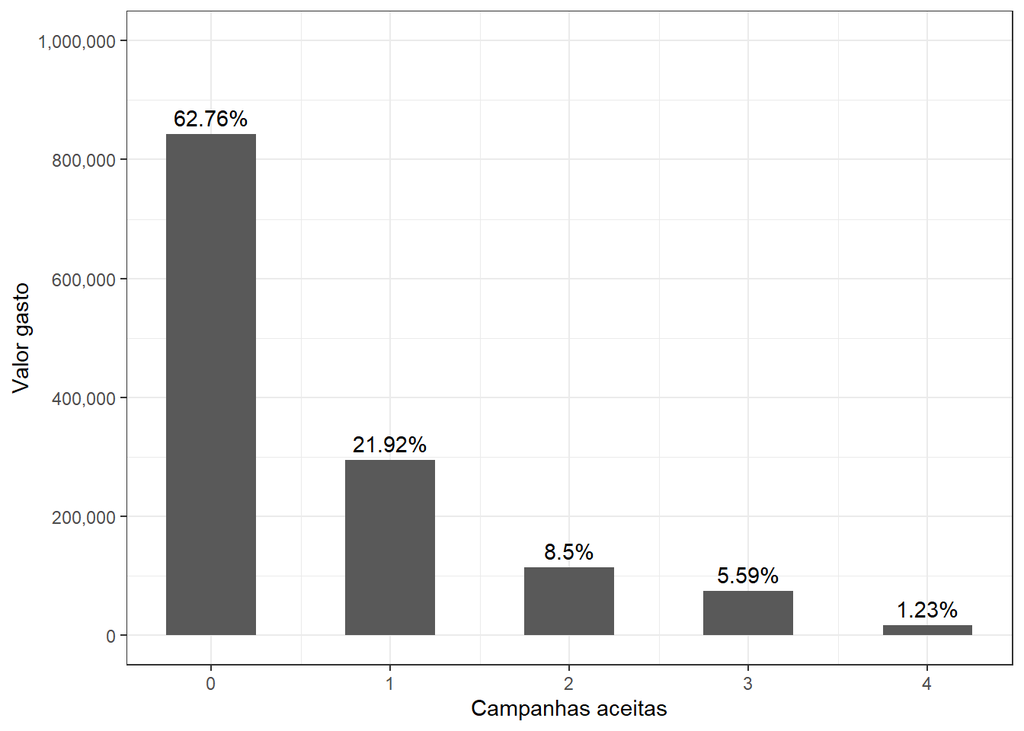

```r
# gasto pelo número de campanhas aceitas
Gst_campaign_acc <- df_eda_1 %>%
  group_by(Num_campaign_acc) %>% summarise(Gasto_camp_acc = sum(Gasto_total)) %>%
  mutate(perc_gasto_camp = round((Gasto_camp_acc/sum(Gasto_camp_acc))*100,2),
         perc_lab = paste0(perc_gasto_camp,"%"))

ggplot(data = Gst_campaign_acc) +
  geom_col(aes(x = Num_campaign_acc,y = Gasto_camp_acc), width = 0.5) +
  labs(x = "Campanhas aceitas",y = "Valor gasto") +
  theme_bw() + geom_text(aes(x = Num_campaign_acc,y = Gasto_camp_acc,label = perc_lab), vjust = -0.5) +
  scale_y_continuous(limits = c(0,1000000), breaks = c(0,200000,400000,600000,800000,1000000),
                     labels = scales::comma)
```

## 4.2 Gráfico de dispersão

```r
df_eda_1 %>% group_by(Education) %>% count()
```

| Education | n |
| --- | --- |
| Postgraduate | 1954 |
| Undergraduate | 252 |

```r
df_eda_1 %>% group_by(Marital_Status) %>% count()
```

| Marital_Status | n |
| --- | --- |
| Alone | 780 |
| In couple | 1426 |

```r
df_eda_1 %>% group_by(Has_Children) %>% count()
```

| Has_Children | n |
| --- | --- |
| Has child | 1578 |
| No child | 628 |

```r
df_eda_1 %>% group_by(Children) %>% count()
```

| Children | n |
| --- | --- |
| 1 children | 1113 |
| 2 children | 415 |
| 3 children | 50 |
| No children | 628 |

### 4.2.1 Renda anual x Valor médio por compra

- Disciminando por educacão

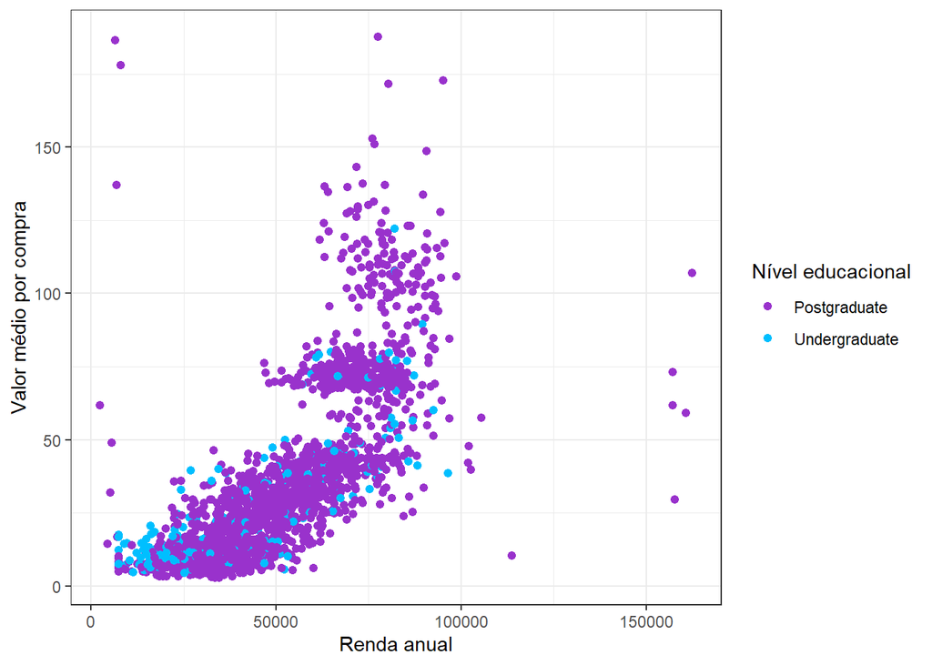

```r
ggplot(data = df_eda_1) +
  geom_point(aes(x = Income, y = Valor_medio_de_compra, color = Education),size=1.8) +
  labs(x="Renda anual",y="Valor médio por compra") +
  theme_bw() +
  scale_colour_manual("Nível educacional", values = c("darkorchid","deepskyblue1"))
```

- Disciminando por quantidade de filhos

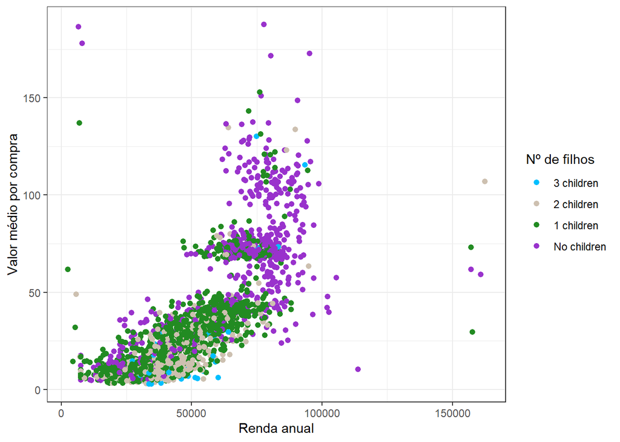

```r
df_eda_1$Children <- factor(df_eda_1$Children, levels = c("3 children","2 children",
                                                          "1 children","No children"))


ggplot(data = df_eda_1) +
  geom_point(aes(x = Income, y = Valor_medio_de_compra, color = Children),size=1.8) +
  labs(x="Renda anual",y="Valor médio por compra") +
  theme_bw() +
  scale_colour_manual("Nº de filhos", values = c("deepskyblue1","antiquewhite3","forestgreen","darkorchid"))
```

### 4.2.2 Renda anual x Gasto total

- Disciminando por quantidade de filhos

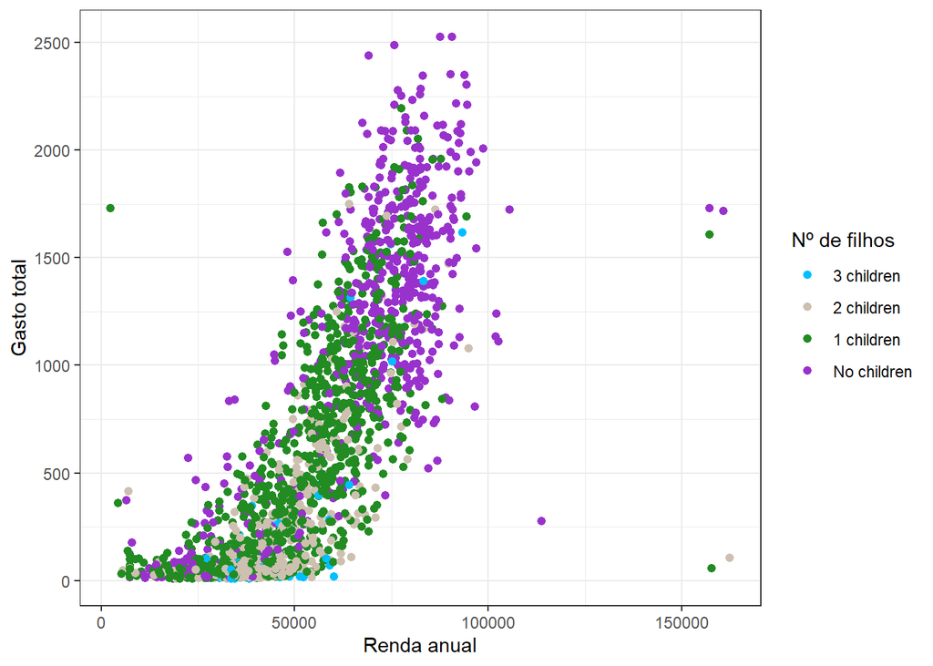

```r
ggplot(data = df_eda_1) +
  geom_point(aes(x = Income, y = Gasto_total, color = Children),size=1.8) +
  labs(x="Renda anual",y="Gasto total") +
  theme_bw() +
  scale_colour_manual("Nº de filhos", values = c("deepskyblue1","antiquewhite3","forestgreen","darkorchid"))
```

# 5 Correlação entre variáveis

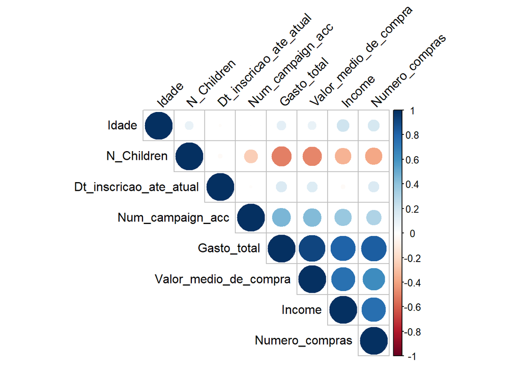

```r
xy <- df_eda_1 %>% select("Idade","N_Children","Income","Numero_compras","Gasto_total",
                         "Num_campaign_acc","Dt_inscricao_ate_atual","Valor_medio_de_compra")

correlacao <- cor(xy)
corrplot(correlacao, type = "upper", order = "hclust",
         tl.col = "black", tl.srt = 45)
```

# 6 Gerar clusters

## 6.1 Renda Anual e gasto total

```r
X1 = data.frame(Renda_anual = df_eda_1$Income,
               Gasto_em_compras = df_eda_1$Gasto_total)

X1 = scale(X1)
```

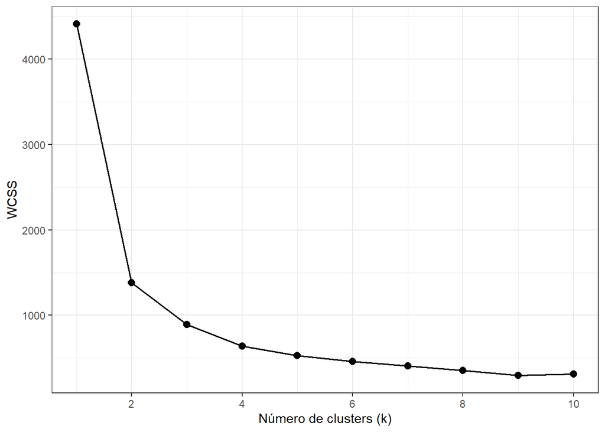

```r
set.seed(1)
wcss = vector()
for (i in 1:10) {
  kmeans = kmeans(x = X1, centers = i)
  wcss[i] = sum(kmeans$withinss)
}

ggplot(data = data.frame(n = c(1:10),WCSS = wcss),aes(x = n, y=WCSS)) +
  geom_line(size=0.7,linetype = 1,lineend   = "round",linejoin = "round",linemitre=1) +
  geom_point(size = 2.5) +
  labs(x="Número de clusters (k)",y="WCSS") +
  scale_x_continuous(breaks = seq(0,10,2)) +
  theme_bw()
```

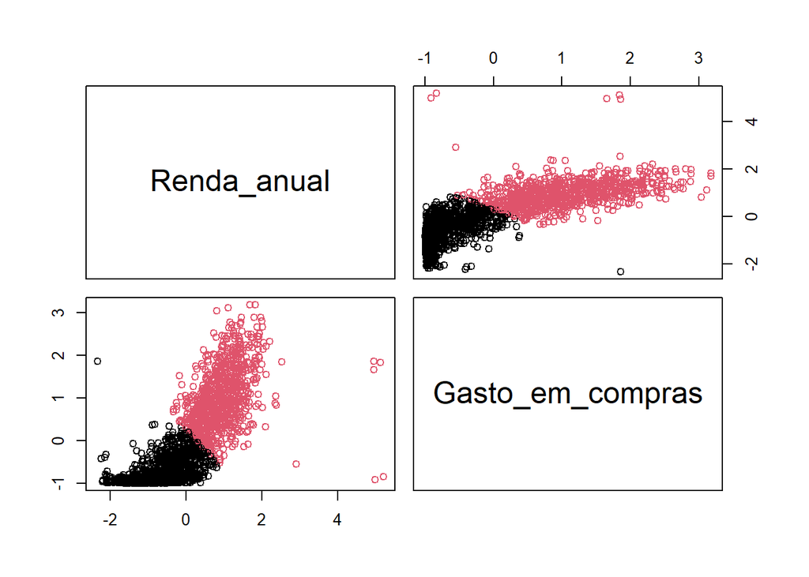

```r
set.seed(3)
kmeans = kmeans(x = X1, centers = 2)
previsoes = kmeans$cluster

X1 <- as.data.frame(X1)

pairs(X1, col = c(1:4)[previsoes])
```

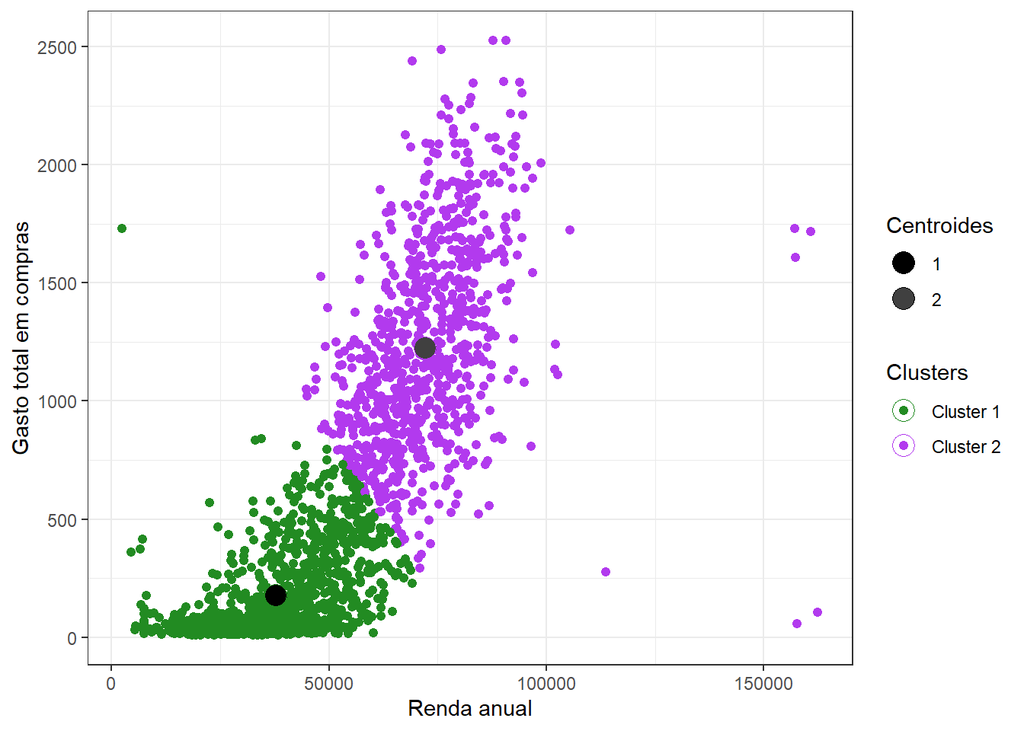

```r
df_resumo <- data.frame(Income=df_eda_1$Income,Gasto_total=df_eda_1$Gasto_total,Previsoes=previsoes) %>%
  group_by(Previsoes) %>%
  summarise(Renda_media= mean(Income), Gasto_medio = mean(Gasto_total))

previsoes = as.factor(previsoes)
df_resumo$Previsoes = as.factor(df_resumo$Previsoes)
ggplot(data = df_eda_1) +
  geom_point(aes(x=Income,y=Gasto_total,color=previsoes,fill=previsoes),size=1.8,shape=19) +
  geom_point(data=df_resumo, aes(x=Renda_media,y=Gasto_medio,color=Previsoes,fill=Previsoes), size = 5,shape=21) +
  labs(x="Renda anual",y="Gasto total em compras") +
  scale_colour_manual("Clusters",values = c("forestgreen","darkorchid2"),
                      labels = c("Cluster 1", "Cluster 2")) +
  scale_fill_manual(name="Centroides", values=c("black","gray25")) + theme_bw()
```

## 6.2 Renda Anual e Idade

```r
X2 = data.frame(Renda_anual = df_eda_1$Income,
                Idade = df_eda_1$Idade)

X2 = scale(X2)
```

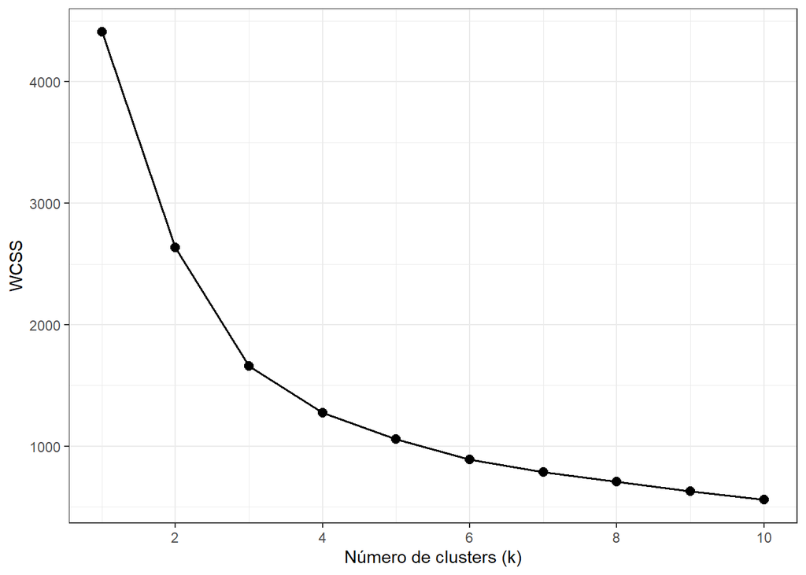

```r
set.seed(1)
wcss2 = vector()
for (i in 1:10) {
  kmeans2 = kmeans(x = X2, centers = i)
  wcss2[i] = sum(kmeans2$withinss)
}

ggplot(data = data.frame(n = c(1:10),WCSS = wcss2),aes(x = n, y=WCSS)) +
  geom_line(size=0.7,linetype = 1,lineend   = "round",linejoin = "round",linemitre=1) +
  geom_point(size = 2.5) +
  labs(x="Número de clusters (k)",y="WCSS") +
  scale_x_continuous(breaks = seq(0,10,2)) +
  theme_bw()
```

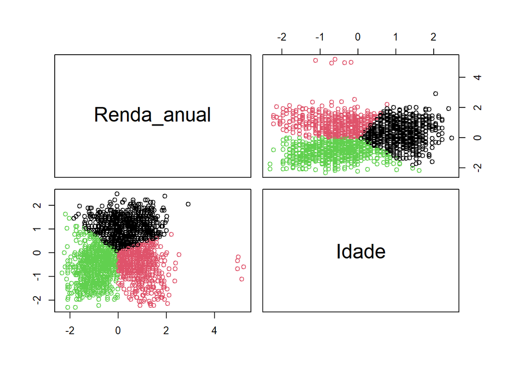

```r
set.seed(3)
kmeans2 = kmeans(x = X2, centers = 3)
previsoes2 = kmeans2$cluster

X2 <- as.data.frame(X2)

pairs(X2, col = c(1:4)[previsoes2])
```

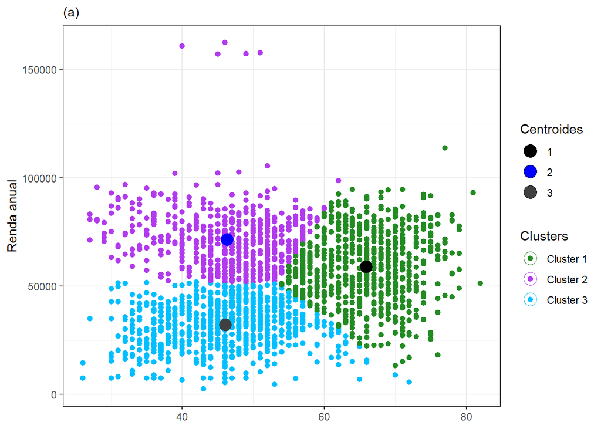

```r
df_resumo2 <- data.frame(Income=df_eda_1$Income,Gasto_total=df_eda_1$Gasto_total,Previsoes=previsoes2,Idade=df_eda_1$Idade) %>% group_by(Previsoes) %>%
  summarise(Renda_media= mean(Income), Gasto_medio = mean(Gasto_total),Idade_media = mean(Idade), max_renda =max(Income))


previsoes2 = as.factor(previsoes2)
df_resumo2$Previsoes = as.factor(df_resumo2$Previsoes)
ggplot(data = df_eda_1) +
  geom_point(aes(y=Income,x=Idade,color=previsoes2,fill=previsoes2),size=1.8,shape=19) +
  geom_point(data=df_resumo2, aes(y=Renda_media,x=Idade_media,color=Previsoes,fill=Previsoes), size = 5,shape=21) +
  labs(y="Renda anual",x=NULL, subtitle = "(a)") +
  scale_colour_manual("Clusters",values = c("forestgreen","darkorchid2","deepskyblue1","black","red"),
                      labels = c("Cluster 1", "Cluster 2","Cluster 3")) +
  scale_fill_manual(name="Centroides", values=c("black","blue","gray25","white","red")) + theme_bw()
```

## 6.3 Gasto total e Idade

```r
X3 = data.frame(Gasto = df_eda_1$Gasto_total,
                Idade = df_eda_1$Idade)

X3 = scale(X3)
```

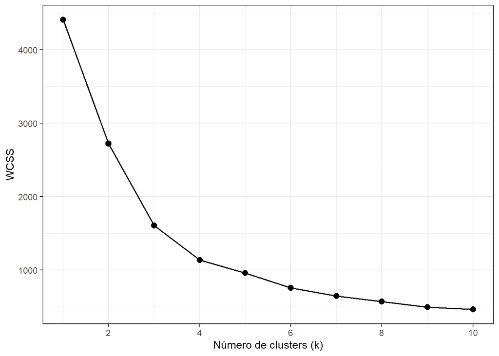

```r
set.seed(1)
wcss3 = vector()
for (i in 1:10) {
  kmeans3 = kmeans(x = X3, centers = i)
  wcss3[i] = sum(kmeans3$withinss)
}
ggplot(data = data.frame(n = c(1:10),WCSS = wcss3),aes(x = n, y=wcss3)) +
  geom_line(size=0.7,linetype = 1,lineend   = "round",linejoin = "round",linemitre=1) +
  geom_point(size = 2.5) +
  labs(x="Número de clusters (k)",y="WCSS") +
  scale_x_continuous(breaks = seq(0,10,2)) +
  theme_bw()
```

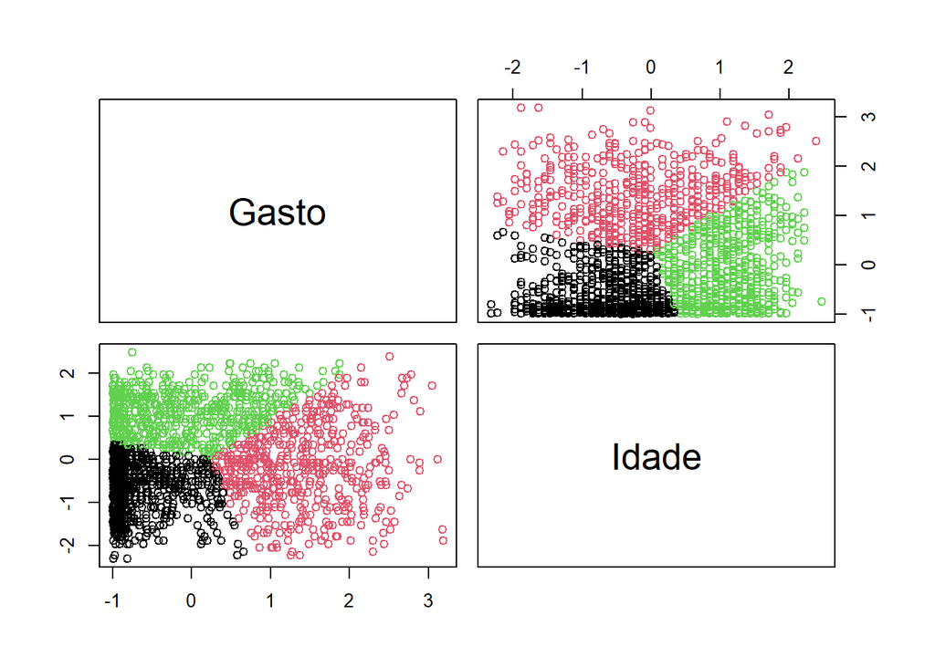

```r
set.seed(3)
kmeans3 = kmeans(x = X3, centers = 3)
previsoes3 = kmeans3$cluster

X3 <- as.data.frame(X3)

pairs(X3, col = c(1:4)[previsoes3])
```

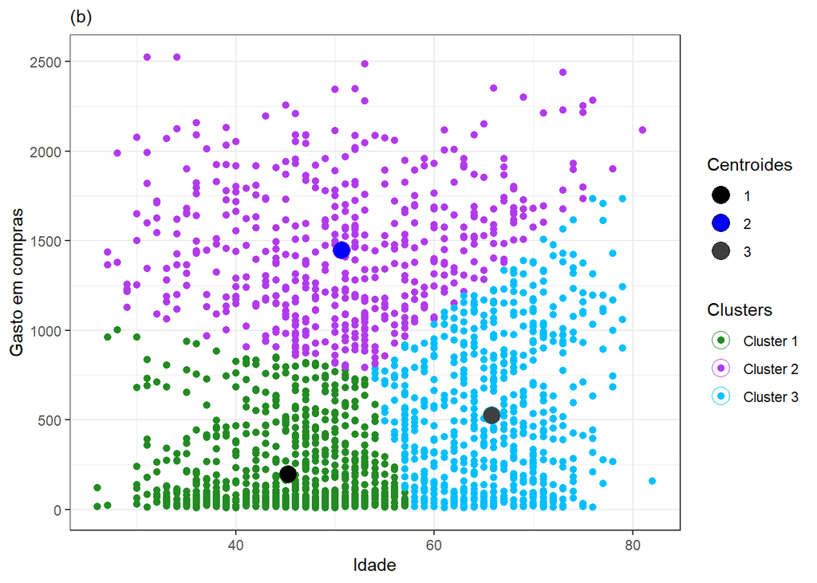

```r
df_resumo3 <- data.frame(Income=df_eda_1$Income,Gasto_total=df_eda_1$Gasto_total,Previsoes=previsoes3,Idade=df_eda_1$Idade) %>%  group_by(Previsoes) %>%
  summarise(Renda_media= mean(Income), Gasto_medio = mean(Gasto_total),Idade_media = mean(Idade))

previsoes3 = as.factor(previsoes3)
df_resumo3$Previsoes = as.factor(df_resumo3$Previsoes)
ggplot(data = df_eda_1) +
  geom_point(aes(y=Gasto_total,x=Idade,color=previsoes3,fill=previsoes3),size=1.8,shape=19) +
  geom_point(data=df_resumo3, aes(y=Gasto_medio,x=Idade_media,color=Previsoes,fill=Previsoes), size = 5,shape=21) +
  labs(y="Gasto em compras",x="Idade", subtitle = "(b)") +
  scale_colour_manual("Clusters",values = c("forestgreen","darkorchid2","deepskyblue1","black","red"),
                      labels = c("Cluster 1", "Cluster 2","Cluster 3")) +
  scale_fill_manual(name="Centroides", values=c("black","blue","gray25","white","red")) + theme_bw()
```